# Lab 16.2

Bryshal Moore

2026-02-26

```r
library(tidyverse)
library(janitor)
library(dplyr)
library(readr)
```

# Lab 16.2 Introduction to NCBI

The **National Center for Biotechnology Information (NCBI)** is a branch of the U.S. National Library of Medicine. It maintains some of the most widely used databases in all of biology, including:

Think of NCBI as a large, *semi-organized* library of biological data. When a researcher sequences a new organism, they deposit their sequences here so the entire scientific community can use them.

**Website:** https://www.ncbi.nlm.nih.gov

## Learning Goals

**At the end of this exercise, you will be able to:** 1.Describe what NCBI is and why it is important in biology. 2.Perform a BLAST search on the NCBI website and interpret the results. 3.Identify the five major BLAST types and choose the correct one for a given query.

In this lesson, you will be introduced to NCBI — the world’s largest repository of biological sequence data — and incorporate the use of command line to work with genomic data.

## Resources

- [NCBI Help Manual](https://www.ncbi.nlm.nih.gov/books/NBK3831/)
- [BLAST Documentation](https://blast.ncbi.nlm.nih.gov/doc/blast-help/)

## BLAST — Basic Local Alignment Search Tool

**BLAST** is a tool that finds sequences in a database that are similar to a query sequence you provide. It works by breaking your query into short “words,” finding exact matches in the database, and then extending those matches to find the best local alignment.

Its like a search engine, but instead of searching for words in web pages, it searches for sequence similarity in biological databases.

### The Five BLAST Types

There are five main types of BLAST, each designed for a specific combination of query type and database type:

| BLAST Type | Query | Database | Best Used When… |
| --- | --- | --- | --- |
| **blastn** | Nucleotide | Nucleotide | You have a DNA/RNA sequence and want to find similar DNA/RNA sequences |
| **blastp** | Protein | Protein | You have a protein sequence and want to find similar proteins |
| **blastx** | Nucleotide (translated) | Protein | You have a DNA sequence and want to search for similar proteins (BLAST translates your DNA in all 6 reading frames) |
| **tblastn** | Protein | Nucleotide (translated) | You have a protein and want to find the gene(s) that might encode it in a nucleotide database |
| **tblastx** | Nucleotide (translated) | Nucleotide (translated) | You have a DNA sequence and want to find distantly related DNA sequences by comparing at the protein level |

> 💡 **How to remember them:** - The **“n”** in blastn and tblastn refers to **nucleotide** - The **“p”** in blastp refers to **protein** - The **“x”** means **translation** is happening - The **“t”** prefix means the **database** is being translated

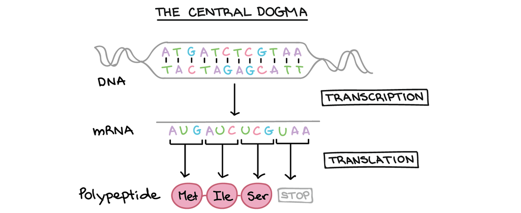

The Central Dogma. Source: Khan Academy

### Let’s run a BLAST Search

**Step-by-step instructions:**

1. Go to https://blast.ncbi.nlm.nih.gov
2. Click the appropriate Nucleotide Blast (blastn)
3. Select the folder that contains our query sequence, **unknown_genome_01.txt** or paste the sequence in the **Enter Query Sequence** text box.
4. Under **“Database”**, make sure it is set for **core nucleotide database(core_nt)**. Optimize for “Highly similar sequences (megablast)”.Under “Algorithm parameters”, set the “Max target sequences” to 50.
5. Click the **“BLAST”** button and wait for results (this can take 30 seconds to several minutes).
6. Examine your results: -**Max Score** - the highest alignment score between your query and a database sequence. (Higher is better.)
   - **Total Score** — the sum of scores for all alignments between your query and a database sequence. (Higher is better.)
   - **E-value** — parameter that describes the number of hits one can “expect” to see by chance when searching a database of a particular size. (Lower is better)
   - **% Identity** — what percentage of aligned positions match exactly.
   - **Query Cover** — what percentage of your query sequence is covered by the alignment.
   - **Accession Number** — a unique identifier for the database entry that matched your query. You can click on this to learn more about the sequence.
7. Check the **Select All** box. Click on Download and select the **Alginment Descrptions CSV**. Download the results in CSV format. Using the command line move the file into your “data/blast_results” folder and rename the file to “genome01_blastn.csv”.

```r
#mv BIS15L_W26_andreigraham/lab16/data/blast_results/ls
#mv genome01_blastn.csv BIS15L_W26_andreigraham/lab16/data/blast_results/ls
```

Load the blast search results into R.

```r
#read_csv("data/blast_results/genome01_blastn.csv")
```

```r
#genome01_blastn<- read_csv("data/blast_results/genome01_blastn.csv")
```

```r
#glimpse
```

What was the top 5 hits for your blast search ?

```r
#genome01_blastn%>%
#  head(n=5)
```

Which hit had the highest e-value?**(include the description, e_value, and link to the accession number for this hit)**

```r
#genome01_blastn%>%
#  select(description, e_value, accession)%>%
#  arrange(esc(e_value))%>%
#  slice_head(n=1)
```

### View Fasta Files in R

#### Install Biostrings

```r
if (!requireNamespace("BiocManager", quietly = TRUE))
  install.packages("BiocManager")

BiocManager::install("Biostrings")
```

Load Library

```r
library(Biostrings)
```

Lets take a look at a dna fasta file

```r
dna_file<- readDNAStringSet("e.coli_genbank.fasta")
```

Lets look at the head of the fasta file

```r
head(dna_file)
```

```
## DNAStringSet object of length 1:
##       width seq                                             names
## [1] 4641652 AGCTTTTCATTCTGACTGCAAC...AACGCCTTAGTAAGTATTTTTC NC_000913.3 Esche...
```

```r
names(dna_file)
```

```
## [1] "NC_000913.3 Escherichia coli str. K-12 substr. MG1655, complete genome"
```

Lets take a look at a amino acid fasta file

```r
aa_file<- readAAStringSet("e.coli_coding_seq.fasta")
```

```r
names(aa_file)
```

[output not shown]

[output cut: 4303 more lines]

Lets try Protein Blast (blastp). *(use unknown_aminoaacid_sequence.txt as the query and the “RefSeq Protein” `refseq_protein` database, use the blastp Algorithm)*.

## Practice *(if time allows)*

1.Download the **Description Table** in CSV format, change the name to “blastp_results.csv” using command line and store the results in the “blast_results” folder. What commands did you use to change the name and move the file into the blast_results folder?

2. Read the csv file into R and clean the column names. Save the cleaned data frame as `blastp_results`.
3. Now try tblastn with the same query and database, use the core nucleotide database (core_nt) database? Download the **Description Table** in CSV format, change the name to “tblastn_results.csv” using command line and store the results in the “blast_results” folder. What commands did you use to change the name and move the file into the blast_results folder?
4. What were the top 20 hits, based on e_value, for each blast search? How do they compare? *(Hint: the description column)*

### That’s it! Let’s take a break and then move on to to the homework.

–>[Home](https://jmledford3115.github.io/datascibiol/)